# Relatório sobre as dataset Hipóxias

Author

João Dionísio

Published

September 10, 2022

# Relatório sobre as dataset Hipóxias

Este relatório foi criado no dia 10 setembro 2022. Foi utilizado a base de dados chamado de hypoxia que se encontra referida na sua forma base com o nome hipoxia.xlsx.

```r
# Exercicio
# 1. Criar um projecto com o nome hipoxia
# 2. Criar um relatorio em html ou docx conforme a preferencia
# 3. Devem explorar o dataset hypoxia.xlsx
# 4. Nesse dataset devem explorar diferencas entre os doentes por tipo de cirurgia Type Surg
# 5. Devem explorar nao so caracteristicas como outcomes
# 6. em de apresentar representacoes graficas (3 graficos diferentes) e tabelas (2 tabelas) T
# 7. Devem utilizar um modelo de regressao para avaliar se ha diferencas entre o valor de BMI por tipo de cirurgia ajustado pra sexo e idade
# 8. O documento docx ou html deve conter pelo menos, titulos, equacoes, listas e imagem p.e. um doente tipo com CPAP
```

## Instalar e Carregar Bibliotecas

```r
# SOURCE: https://cedricscherer.netlify.app/2019/05/17/the-evolution-of-a-ggplot-ep.-1/#aim

# Packages
required_packages <- c(
                       "tidyverse",
                       "broom",
                       "table1",
                       "readxl",
                       #"lubridate",
                       "kableExtra",
                       "patchwork",
                       "MLDataR",
                       "here",
                       "ggthemes"
                       #"tidyverse"
                       )
#ploty
for (pkg in required_packages) {
  # install packages if not already present
  if (!pkg %in% rownames(installed.packages())) {
    install.packages(pkg)
  }

  # load packages to this current session
  library(pkg, character.only = TRUE)
}
```

Para uma questão de coerência e para não me esquecer no futuro deixo a seed definida para possíveis análises e a limpeza do environment.

```r
set.seed(123)

#### Clean enviorment


rm(list = ls(all.names = TRUE)) #will clear all objects includes hidden objects.
```

## Explorar o dataset hypoxia.xlsx

```r
hypoxia <- read_excel("datasets/hypoxia.xlsx")
View(hypoxia)
```

Limpeza das variáveis

```r
#install.packages("janitor")
library(janitor)
hypoxia_1 <- janitor::clean_names(hypoxia)
```

```r
hipoxia_lite <- hypoxia_1 %>%
  select(age,
         female,
         race,
         bmi,
         sleeptime,
         min_sao2,
         diabetes,
         smoking,
         hyper,
         cad,
         cpap,
         type_surg)


#Penso que sera possivel simplificar este cofigo
#

#mulheres
unit_female <- hipoxia_lite %>%
  summarise(female_mean= round(mean(female),2))


a <- unit_female*100
#fumadores
unit_smokers <- hipoxia_lite %>%
  summarise(smokers_mean= round(mean(smoking),2))

b <- unit_smokers*100

#hipertensos
unit_hta <- hipoxia_lite %>%
  summarise(hyper_mean= round(mean(hyper),2))

c <- unit_hta*100

#CAD
unit_diabetes <- hipoxia_lite %>%
  summarise(db_mean= round(mean(diabetes),2))

d <- unit_diabetes*100

#CPAP
unit_cpap <- hipoxia_lite %>%
  summarise(cpap_mean = round(mean(cpap),2))

e <- unit_cpap*100
  #footnote(general = "Here is a general comments of the table. ",
# Poderiamos ter

#library(table1)

#t1<- table1(~ factor(sex) +
 #        age +
  #       factor(resting_ecg) +
   #      cholesterol +
    #     resting_bp |
     #    heart_disease,
      # data=hd,
      # footnote = "Source: MLData R",
       #caption = "Descriptive variables by health disease"
      # )

#library(openxlsx)
#t1
#table1 <- as.data.frame(t1)
#write.xlsx(table1, file = here::here("outputs",
 #                 paste0("table1_", Sys.Date(),".xlsx"))
  #         )
```

### Dados descritivos de variáveis binárias - em percentagem

A percetagem de mulheres no dataset é 72%

A percetagem de fumadores no dataset é 50%

A percetagem de diabeticos no dataset é 35%

A percetagem de hipertensos no dataset é 71%

A percentagem de utilizadores de CPAP 63%

Exemplo de tabela discritiva

```r
race_df <- hipoxia_lite %>%
  group_by(race) %>%
  summarise(cases_race=n())%>%
  mutate(race = case_when(
    race == 1 ~ "African American",
    race == 2 ~ "Caucasian",
    race == 3 ~ "Other"
  ))%>%
  rename("Race" = race)%>%
  rename("N()"= cases_race)

table_race <- race_df %>%
  kbl(digits = 2 # casas decimais
      ,caption = "Número de individuos, por raça") %>%
  kable_classic(full_width = F, #mantem numa linha
                html_font = "Calibri")

table_race
```

Número de individuos, por raça

| Race | N() |
| --- | --- |
| African American | 57 |
| Caucasian | 216 |
| Other | 8 |

## Explorar diferencas entre os doentes por tipo de cirurgia Type Surg

```r
type_surg_df <- hipoxia_lite %>%
  mutate(type_surg = case_when(
    type_surg == 1 ~ "Gastroenterostomy",
    type_surg == 2 ~ "Gastric restrictive procedure",
    type_surg == 3 ~ "Gastroplasty",
    type_surg == 4 ~ "Removal of gastric restrictive device",
  ))%>%
  group_by(type_surg)

total_cirurgias <- type_surg_df %>%
  summarise("N" = n())%>%
  summarise(N= sum(N))

total_cirurgias_N <- pull(total_cirurgias,1)

type_surg_df_N <- type_surg_df %>%
  summarise(N = n())%>%
  arrange(desc(N))%>%
  mutate(
   Percentagem = N / total_cirurgias_N *100)

#quero adicionar a percetagem de cada cirurgia no total

table_surg_N <- type_surg_df_N %>%
  kbl(digits = 2 # casas decimais
      ,caption = "Número de cirurgias por tipo de procedimento") %>%
  kable_classic(full_width = F, #mantem numa linha
                html_font = "Calibri")

type_surg_df_fem <- type_surg_df  %>%
  summarise(percent_sex=mean(female, na.rm = TRUE)*100)%>%
  arrange(percent_sex)

table_surg_female <- type_surg_df_fem %>%
  kbl(digits = 2 # casas decimais
      ,caption = "Percentagem de mulheres por tipo de cirurgia") %>%
  kable_classic(full_width = F, #mantem numa linha
                html_font = "Calibri")

type_surg_df_bmi <- type_surg_df  %>%
  summarise(mean_bmi=mean(bmi, na.rm = TRUE),
            sd_bmi=sd(bmi, na.rm = TRUE),
            min_bmi=min(bmi, na.rm = TRUE),
            max_bmi=max(bmi, na.rm = TRUE)
            )%>%
  rename("Média de BMI"= mean_bmi,
         "DP do BMI"= sd_bmi,
         "Min"=min_bmi,
         "Max"=max_bmi,
         "Tipo de cirurgia"= type_surg)

table_surg_bmi <- type_surg_df_bmi %>%
  kbl(digits = 3 # casas decimais
      ,caption = "Índice de Massa Corporal por cirurgia,(média, desvio-padrão, minimo e máximo)") %>%
  kable_classic(full_width = F, #mantem numa linha
                html_font = "Calibri")

type_surg_df_age <- type_surg_df  %>%
  summarise(mean_age=mean(age, na.rm = TRUE),
            sd_age=sd(age, na.rm = TRUE),
            min_age=min(age, na.rm = TRUE),
            max_age=max(age, na.rm = TRUE)
            )%>%
  rename("Média de Idade"= mean_age,
         "DP da Idade"= sd_age,
         "Min"=min_age,
         "Max"=max_age)

table_surg_age <- type_surg_df_age %>%
  kbl(digits = 3 # casas decimais
      ,caption = "Idade por cirurgia,(média, desvio-padrão, minimo e máximo)") %>%
  kable_classic(full_width = F, #mantem numa linha
                html_font = "Calibri")

# colocar tabela em baixo
sum_race <- hipoxia_lite %>%
    group_by(type_surg,race) %>%
    summarise(n_race=dplyr::n()
    )

sum_race <- sum_race %>%
  mutate(
    race = case_when(
      race ==1 ~ "N_African_American",
      race ==2 ~ "N_Caucasian",
      race ==3 ~ "N_Other_race"
      )
  )

sum_race <- sum_race %>%
pivot_wider(names_from = race, values_from = n_race)

sum_race <- sum_race %>%
  mutate(
    N_African_American = ifelse(is.na(N_African_American), 0, N_African_American),
    N_Caucasian = ifelse(is.na(N_Caucasian), 0, N_Caucasian),
    N_Other_Race = ifelse(is.na(N_Other_race), 0, N_Other_race)
  )%>%
  mutate(type_surg = case_when(
    type_surg == 1 ~ "Gastroenterostomy",
    type_surg == 2 ~ "Gastric restrictive procedure",
    type_surg == 3 ~ "Gastroplasty",
    type_surg == 4 ~ "Removal of gastric restrictive device",
  ))

table_surg_race <- sum_race %>%
  kbl(digits = 2 # casas decimais
      ,caption = "Distribuição de utentes por raça e por tipo de cirurgia") %>%
  kable_classic(full_width = F, #mantem numa linha
                html_font = "Calibri")
#sum_hypoxia <- left_join(sum_hypoxia, sum_race, by="type_surg")
```

###Número de Cirurgias, por N e por percentagem do total

```r
table_surg_N
```

Número de cirurgias por tipo de procedimento

| type_surg | N | Percentagem |
| --- | --- | --- |
| Gastroenterostomy | 225 | 80.07 |
| Gastric restrictive procedure | 51 | 18.15 |
| Gastroplasty | 3 | 1.07 |
| Removal of gastric restrictive device | 2 | 0.71 |

```r
nome_cirur_ref <- first(type_surg_df_N$type_surg)
numero_cirur_ref <- first(type_surg_df_N$N)
percent_cirur_ref <- first(type_surg_df_N$Percentagem,1)
```

O número de cirurgias total foi *281* com a intervenção de referência a ser a *Gastroenterostomy* com *225* compondo *80.0711744* do total de cirurgias.

###Percentagem de utentes femininos por tipo de cirurgia

```r
# colocar aqui as tabelas dos primeiras
table_surg_female
```

Percentagem de mulheres por tipo de cirurgia

| type_surg | percent_sex |
| --- | --- |
| Gastric restrictive procedure | 62.75 |
| Gastroplasty | 66.67 |
| Gastroenterostomy | 73.33 |
| Removal of gastric restrictive device | 100.00 |

###Distribuição de utentes por raça e por tipo de cirurgia

```r
# colocar aqui as tabelas dos primeiras
table_surg_race
```

Distribuição de utentes por raça e por tipo de cirurgia

| type_surg | N_African_American | N_Caucasian | N_Other_race | N_Other_Race |
| --- | --- | --- | --- | --- |
| Gastroenterostomy | 43 | 176 | 6 | 6 |
| Gastric restrictive procedure | 12 | 38 | 1 | 1 |
| Gastroplasty | 2 | 1 | NA | 0 |
| Removal of gastric restrictive device | 0 | 1 | 1 | 1 |

###Média e desvio-padrão do Índice de Massa corporal, por tipo de cirurgia

```r
table_surg_bmi
```

Índice de Massa Corporal por cirurgia,(média, desvio-padrão, minimo e máximo)

| Tipo de cirurgia | Média de BMI | DP do BMI | Min | Max |
| --- | --- | --- | --- | --- |
| Gastric restrictive procedure | 43.794 | 6.323 | 34.0 | 71.7 |
| Gastroenterostomy | 47.391 | 8.007 | 23.4 | 70.1 |
| Gastroplasty | 48.233 | 2.173 | 45.9 | 50.2 |
| Removal of gastric restrictive device | 47.600 | 2.546 | 45.8 | 49.4 |

```r
#Nao aplicar já fazer se for para pôr valores em inline
#list_types <- c("Gastroenterostomy","Gastric restrictive procedure","Gastroplasty","Removal of gastric restrictive device")

#var_names <- paste0("r", 1:4)

#for (i in seq_along(var_names)){
 # assign(var_names[[i]], sum_hypoxia %>% filter(type_surg==list_types[[i]]) %>% pull(n_surgeries))
#}
```

###Tabelas discritivas com o table 1

Após fazer algumas tabelas com o Kable Extras decidi mudar para o table 1

```r
hypoxia_2_descrip <- hypoxia_1 %>%
  mutate(type_surg = as.factor(type_surg))%>%
  mutate(type_surg = case_when(
    type_surg == 1 ~ "Gastroenterostomy",
    type_surg == 2 ~ "Gastric restrictive procedure",
    type_surg == 3 ~ "Gastroplasty",
    type_surg == 4 ~ "Removal of gastric restrictive device"))


t1<- table1(~ setLabel(factor(female),"Female") +
              setLabel(age,"Age") +
              setLabel(bmi,"BMI") +
              setLabel(factor(race),"Race") +
              setLabel(factor(smoking), "Smoking") +
              factor(diabetes) +
              factor(hyper) +
              factor(cpap)+
              sleeptime |
              `type_surg`,
            data=hypoxia_2_descrip,
      # footnote = "Source: MLData R",
       caption = "Descriptive variables by type of surgery"
       )
t1
```

Descriptive variables by type of surgery

|  | Gastric restrictive procedure (N=51) | Gastroenterostomy (N=225) | Gastroplasty (N=3) | Removal of gastric restrictive device (N=2) | Overall (N=281) |
| --- | --- | --- | --- | --- | --- |
| Female |  |  |  |  |  |
| 0 | 19 (37.3%) | 60 (26.7%) | 1 (33.3%) | 0 (0%) | 80 (28.5%) |
| 1 | 32 (62.7%) | 165 (73.3%) | 2 (66.7%) | 2 (100%) | 201 (71.5%) |
| Age |  |  |  |  |  |
| Mean (SD) | 49.8 (13.8) | 46.9 (10.3) | 33.0 (4.37) | 51.9 (9.83) | 47.3 (11.1) |
| Median [Min, Max] | 51.3 [17.9, 72.9] | 47.8 [16.4, 73.8] | 32.6 [28.9, 37.6] | 51.9 [44.9, 58.8] | 48.2 [16.4, 73.8] |
| BMI |  |  |  |  |  |
| Mean (SD) | 43.8 (6.32) | 47.4 (8.01) | 48.2 (2.17) | 47.6 (2.55) | 46.7 (7.77) |
| Median [Min, Max] | 43.5 [34.0, 71.7] | 47.0 [23.4, 70.1] | 48.6 [45.9, 50.2] | 47.6 [45.8, 49.4] | 46.0 [23.4, 71.7] |
| Race |  |  |  |  |  |
| 1 | 12 (23.5%) | 43 (19.1%) | 2 (66.7%) | 0 (0%) | 57 (20.3%) |
| 2 | 38 (74.5%) | 176 (78.2%) | 1 (33.3%) | 1 (50.0%) | 216 (76.9%) |
| 3 | 1 (2.0%) | 6 (2.7%) | 0 (0%) | 1 (50.0%) | 8 (2.8%) |
| Smoking |  |  |  |  |  |
| 0 | 30 (58.8%) | 105 (46.7%) | 3 (100%) | 2 (100%) | 140 (49.8%) |
| 1 | 21 (41.2%) | 120 (53.3%) | 0 (0%) | 0 (0%) | 141 (50.2%) |
| factor(diabetes) |  |  |  |  |  |
| 0 | 35 (68.6%) | 145 (64.4%) | 3 (100%) | 1 (50.0%) | 184 (65.5%) |
| 1 | 16 (31.4%) | 80 (35.6%) | 0 (0%) | 1 (50.0%) | 97 (34.5%) |
| factor(hyper) |  |  |  |  |  |
| 0 | 16 (31.4%) | 65 (28.9%) | 1 (33.3%) | 0 (0%) | 82 (29.2%) |
| 1 | 35 (68.6%) | 160 (71.1%) | 2 (66.7%) | 2 (100%) | 199 (70.8%) |
| factor(cpap) |  |  |  |  |  |
| 0 | 20 (39.2%) | 80 (35.6%) | 2 (66.7%) | 1 (50.0%) | 103 (36.7%) |
| 1 | 31 (60.8%) | 145 (64.4%) | 1 (33.3%) | 1 (50.0%) | 178 (63.3%) |
| sleeptime |  |  |  |  |  |
| Mean (SD) | 20.2 (24.7) | 18.7 (23.7) | 3.00 (2.21) | 8.95 (4.03) | 18.7 (23.7) |
| Median [Min, Max] | 8.30 [0, 85.4] | 8.10 [0, 99.6] | 3.80 [0.500, 4.70] | 8.95 [6.10, 11.8] | 8.10 [0, 99.6] |

## Representações Gráficas

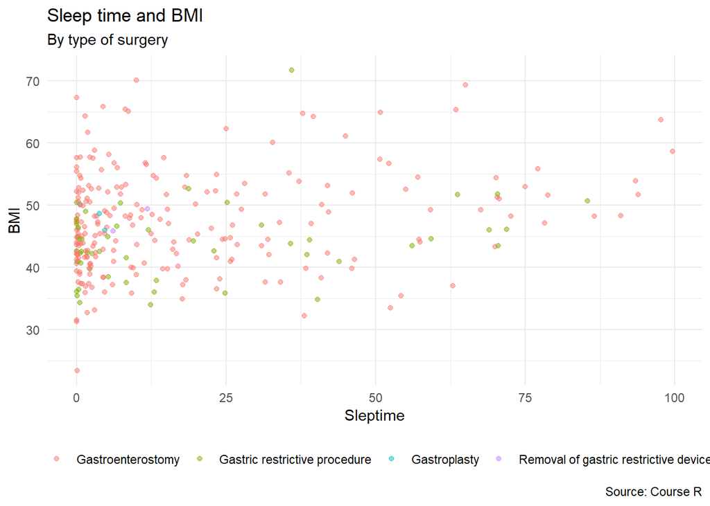

```r
p1<- ggplot(hipoxia_lite,
       aes(x=sleeptime,
           y=bmi,
           colour=as.factor(type_surg))
       )+

  geom_point(alpha=0.5
             ) +


  scale_colour_discrete(labels=c("Gastroenterostomy","Gastric restrictive procedure","Gastroplasty","Removal of gastric restrictive device")) +

    labs(title = "Sleep time and BMI",
         subtitle = "By type of surgery",
         y = "BMI",
         x = "Sleptime",
         caption = "Source: Course R",
       colour="") +
   theme_minimal() +
  theme(legend.position="bottom")

p1
```

###Boxplot com o tempo de cirurgia por tipo de cirurgia

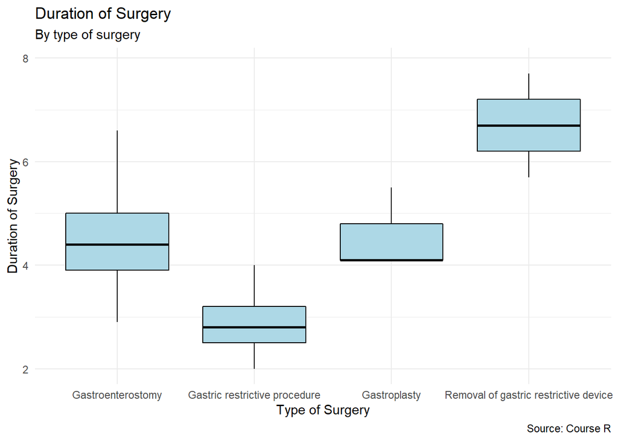

```r
p2<- ggplot() +
  geom_boxplot(data= hypoxia_1,
            aes(x = as.factor(type_surg), y = duration_of_surg ),
            outlier.shape = NA,
            fill = "light blue",
            colour = "black")+
  scale_x_discrete(labels=c("Gastroenterostomy","Gastric restrictive procedure","Gastroplasty","Removal of gastric restrictive device")) +
  labs(title = "Duration of Surgery",
         subtitle = "By type of surgery",
         y = "Duration of Surgery",
         x = "Type of Surgery",
         caption = "Source: Course R",
       colour="") +
  theme_minimal() +
  theme(legend.position="bottom")

p2
```

Uma questão que poderá surgir é se o BMI poderá influenciar o tempo de cirurgia

```r
hipoxia_2 <- hypoxia_1 %>%
  mutate(BMI_cat = case_when(
     bmi = (bmi<18.5) ~ "Underweight",
     bmi = (bmi>=18.5 & bmi<24.5) ~ "Normal",
     bmi = (bmi>=24.5 & bmi<29.9) ~ "Overweight",
     bmi = (bmi>=30) ~ "Obese"
  )
  )

#list_bmi <- c("Underweight","Normal","Overweight","Obese")

#var_names <- paste0("p",3:6)

# for (i in seq_along(var_names)){
# assign(var_names[[i]], ggplot() +
# geom_boxplot(data= hypoxia_1,
#            aes(x = as.factor(type_surg), y = duration_of_surg ),
#            outlier.shape = NA)+ #NEW to Exclude outliers +
# scale_x_discrete(labels=c("Gastroenterostomy","Gastric restrictive procedure","Gastroplasty","Removal of gastric restrictive device")) +
# labs(title = "Duration of Surgery",
#       subtitle = paste0("By type of surgery",",",list_bmi[[i]]),
#      y = "Duration of Surgery",
#     x = "Type of Surgery",
#    caption = "Source: Course R",
# colour="") +
# theme_minimal() +
# theme(legend.position="bottom"))
# }

p3<- ggplot() +
  geom_boxplot(data= hipoxia_2 %>% filter(BMI_cat == "Underweight" | BMI_cat == "Normal"),
            aes(x = as.factor(type_surg),
                y = duration_of_surg ),
                outlier.shape = NA)+
  facet_wrap(~BMI_cat) +#NEW to Exclude outliers +
  scale_x_discrete(labels=c("Gastroenterostomy","Gastric restrictive procedure","Gastroplasty","Removal of gastric restrictive device")) +
  labs(title = "Duration of Surgery",
        subtitle = "By type of surgery",
        y = "Duration of Surgery",
        x = "Type of Surgery",
        caption = "Source: Course R",
        colour="") +
  theme_minimal() +
  theme(legend.position="bottom")


p4 <-ggplot() +
  geom_boxplot(data= hipoxia_2 %>% filter(BMI_cat == "Overweight" | BMI_cat == "Obese"),
            aes(x = as.factor(type_surg),
                y = duration_of_surg ),
                outlier.shape = NA)+
  facet_wrap(~BMI_cat) +#NEW to Exclude outliers +
  scale_x_discrete(labels=c("Gastroenterostomy","Gastric restrictive procedure","Gastroplasty","Removal of gastric restrictive device")) +
  labs(title = "Duration of Surgery",
        subtitle = "By type of surgery",
        y = "Duration of Surgery",
        x = "Type of Surgery",
        caption = "Source: Course R",
        colour="") +
  theme_minimal() +
  theme(legend.position="bottom")


p5<-p3/p4
```

Não se questionem mais porque todos os utentes são obesos com apenas um individuo Normal.

###Relação entre o sleeptime e o minsao2

```r
p7<-ggplot(data = hipoxia_2 %>% drop_na(ahi),
       aes(x=sleeptime,
           y=min_sao2,
           colour= as.factor(ahi))) +
  geom_point(alpha=0.2) +
  geom_smooth( method=lm,
               se=FALSE,
               linetype="dashed"

  )+
  labs(title = "Realationship between Time Slept under <90% and Minimum Sat O2",
         y = "Minimum saturation O2",
         x = "Time spent at Sat. of O2 < 90%",
         caption = "Source: Course R",
       fill="",
       colour="AHI")
  theme_minimal()+
  theme(legend.position="right")
```

[output not shown]

[output cut: 329 more lines]

[output not shown]

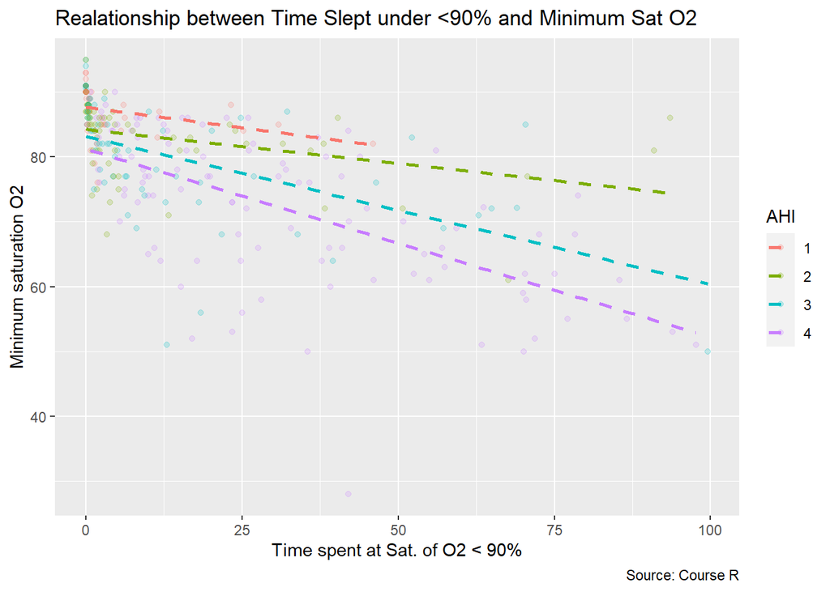

```r
p7
```

## Modelo de regressao para avaliar se ha diferencas entre o valor de BMI por tipo de cirurgia ajustado pra sexo e idade

```r
hipoxia_lite$type_surg <- as.factor(hipoxia_lite$type_surg)# forcar o R a definir tipo de instituicao como variavel categorica

hipoxia_lite$type_surg <- relevel(hipoxia_lite$type_surg, ref = 1)

#hipoxia_lite_mdf <- hipoxia_lite %>%
 # filter()

model2 <- lm(bmi ~
               as.factor(type_surg)+ # variaveis explicativas
               as.factor(female)+
               age,
             data= hipoxia_lite)

# We can with the Broom package make the model object in a tidy model
model2_tidy <- tidy(model2, conf.int = TRUE)

model2_tidy <- model2_tidy %>%
    mutate(
    term = case_when(
      term =="(Intercept)" ~ "Gastroenterostomy(Referência)",
      term =="as.factor(type_surg)2" ~ "Gastric restrictive procedure",
      term =="as.factor(type_surg)3" ~ "Gastroplasty",
      term =="as.factor(type_surg)4" ~ "Removal of gastric restrictive device",
      term =="as.factor(female)1" ~ "Female",
    ))%>%
    filter(!is.na(term))

model2_tidy
```

```
# A tibble: 5 × 7
  term                          estim…¹ std.e…² stati…³  p.value conf.…⁴ conf.…⁵
  <chr>                           <dbl>   <dbl>   <dbl>    <dbl>   <dbl>   <dbl>
1 Gastroenterostomy(Referência)   55.7     2.20  25.3   9.35e-74   51.4   60.0
2 Gastric restrictive procedure   -3.29    1.17  -2.80  5.51e- 3   -5.60  -0.974
3 Gastroplasty                    -1.42    4.40  -0.322 7.48e- 1  -10.1    7.25
4 Removal of gastric restricti…    1.34    5.35   0.250 8.03e- 1   -9.19  11.9
5 Female                          -1.32    1.00  -1.31  1.92e- 1   -3.29   0.663
# … with abbreviated variable names ¹estimate, ²std.error, ³statistic,
#   ⁴conf.low, ⁵conf.high
```

```r
# model2_tidy_sig <- model2_tidy_sig %>%
#     mutate(
#     term = case_when(
#       term =="(Intercept)" ~ "Gastroenterostomy(Referência)",
#       term =="as.factor(type_surg)2" ~ "Gastric restrictive procedure",
#       term =="as.factor(type_surg)3" ~ "Gastroplasty",
#       term =="as.factor(type_surg)4" ~ "Removal of gastric restrictive device",
#       term =="as.factor(female)1" ~ "Female",
#     ))%>%
#     filter(!is.na(term))
# Inspect the model

# The glance function provides the most model diagnostics indicators
model2_glance <-glance(model2)
# Para verificação de resultados
```

```r
# filtrar as colunas significativas e coloca-las em vector para coloca-las como inline no texto
#model2_tidy_sig1 <- model2_tidy_sig %>%
  #filter(p.value<0,05)%>%
  #pull(term)

#model2_tidy_sig1
```

Verifica-se que apenas a Gastric restrictive procedure tem uma diferença signitivamente significativa para o BMI em relação à cirurgia de referência (Gastroenterostomy).

```r
# Lets visualize our model
model2_augment <- augment(model2)

model2_augment
```

```
# A tibble: 281 × 9
     bmi as.factor(type_s…¹ as.fa…²   age .fitted    .hat .sigma .cooksd .std.…³
   <dbl> <fct>              <fct>   <dbl>   <dbl>   <dbl>  <dbl>   <dbl>   <dbl>
 1  44.5 2                  1        29.9    46.4 0.0328    7.52 3.80e-4 -0.259
 2  40.6 1                  1        52.2    46.2 0.00680   7.52 6.40e-4 -0.749
 3  61.7 1                  1        37.3    48.5 0.00807   7.48 4.19e-3  1.76
 4  40.2 1                  1        52.2    46.2 0.00680   7.52 7.35e-4 -0.802
 5  57.6 1                  1        26.7    50.2 0.0171    7.51 2.86e-3  0.993
 6  36   2                  1        54.6    42.5 0.0231    7.51 3.06e-3 -0.882
 7  39.2 1                  1        54      45.9 0.00755   7.51 1.02e-3 -0.899
 8  54.7 1                  1        53.2    46.1 0.00719   7.51 1.61e-3  1.16
 9  43.9 1                  1        47.4    47.0 0.00575   7.52 1.61e-4 -0.408
10  47.2 1                  0        57.4    46.7 0.0161    7.53 1.20e-5  0.0662
# … with 271 more rows, and abbreviated variable names ¹`as.factor(type_surg)`,
#   ²`as.factor(female)`, ³.std.resid
```

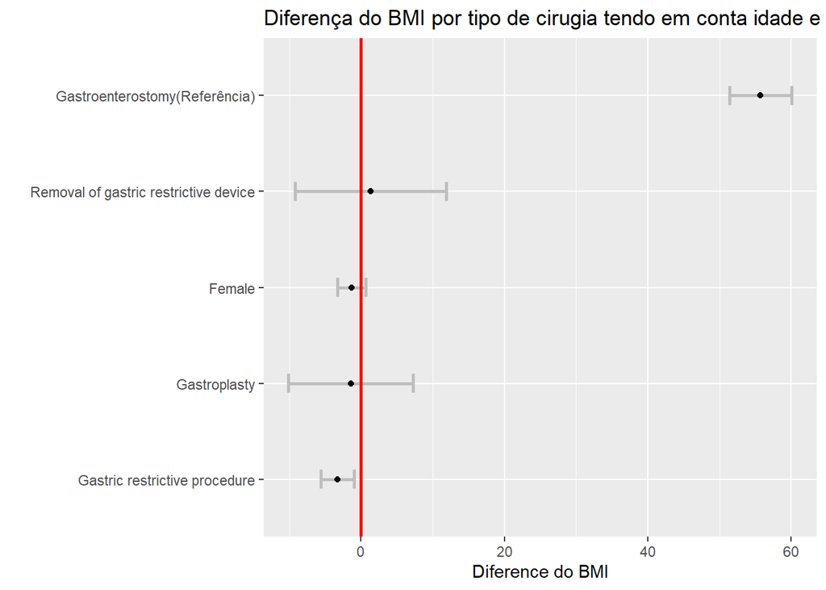

```r
p6<- ggplot(data=model2_tidy,
            aes(x=reorder(term, estimate), y=estimate)) +

         geom_errorbar(aes(ymin=conf.low,
                           ymax=conf.high),
                       width = 0.2,size  = 1,
                       position = "dodge", color="gray") +
  geom_hline(yintercept = 0, color = "red", size = 1) +
  geom_point() +
    labs(title = "Diferença do BMI por tipo de cirugia tendo em conta idade e sexo",
       x = "",
       y = "Diference do BMI") +
  coord_flip()

p6
```

De referir que as cirurgias Removal of gastric restrictive device e Gastroplasty apenas tinham 2 e 3 intervenções que apesar de não terem sido excluídos do modelo limitam a sua análise, podendo existir diferenças.

```r
# hipoxia_lite$type_surg <- as.factor(hipoxia_lite$type_surg)# forcar o R a definir tipo de instituicao como variavel categorica
#
# hipoxia_lite$type_surg <- relevel(hipoxia_lite$type_surg, ref = 1)
#
# model3_logit <- glm(duration_surg ~  bmi +
#                       as.factor(sex)+
#                       as.factor+
#                       resting_bp+
#                       cholesterol,
#                     family="binomial",
#                     data=hd)
#
# model3_tidy <- tidy(model3_logit, exponentiate = TRUE, conf.int = TRUE)
#
# model3_tidy1 <- tidy(model3_logit, exponentiate = FALSE, conf.int = TRUE)
```

## Salvar o gráficos P1 e P2 e P6

```r
ggsave(filename = here::here("outputs", "figures",
                  paste0( "bmi_lm_gastric", ".pdf")),
                  plot= p1,
                  width = 20.49,
                  height = 10.3,
                  units = c("cm"),
                  dpi = "retina")
ggsave( filename = here::here("outputs", "figures",
                  paste0( "Duration of Surgery", ".png")),
                  plot= p2,
                  width = 20.49,
                  height = 10.3,
                  units = c("cm"),
                  dpi = "retina")
ggsave( filename = here::here("outputs", "figures",
                  paste0( "Duration of Surgery", ".png")),
                  plot= p6,
                  width = 20.49,
                  height = 10.3,
                  units = c("cm"),
                  dpi = "retina")
```

## Carregar uma imagem com um doente com um CPAP para sensibilização

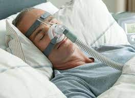

Um doente com CPAP

Consequências da hipóxia

- Dor de cabeça;
- Sonolência;
- Aumento dos batimentos cardíacos;
- Suor frio;
- Falta de ar;
- Tontura;
- Confusão mental;
- Desmaio;
- Dedos e boca arroxeados (cianose).

## Equação

[output not shown]

```r
# 8. O documento docx ou html deve conter pelo menos, titulos, equacoes, listas e imagem p.e. um doente tipo com CPAP
```